# 310.1. Photo-z access and visualization

For the Rubin Science Platform at data.lsst.cloud.  
Data Release: [Data Preview 2](https://dp2.lsst.io/)  
Container Size: Large  
LSST Science Pipelines version: v30.0.10  
Last verified to run: 2026-07-31  
Repository: github.com/lsst/tutorial-notebooks

**Learning objective:** How to access, cross-match, and visualize the LSDB-formatted photo-z.

**LSST data products:** `Object`

**Packages:** `lsdb`

**Credit:** Originally developed by the Rubin Community Science team. Please consider acknowledging them if this notebook is used for the preparation of journal articles, software releases, or other notebooks.

**Get Support:** Everyone is encouraged to ask questions or raise issues in the [Support Category](https://community.lsst.org/c/support) of the Rubin Community Forum. Rubin staff will respond to all questions posted there.

## 1. Introduction

Members of the Rubin Commissioning Science Unit for photometric redshifts have generated photometric redshift (photo-z; PZ) estimates for Data Preview 2 objects using a variety of PZ estimators. These PZ are being made available as LSDB-formatted files, and documented in "Photometric Redshifts for Data Preview 2" [RTN-124](https://rtn-124.lsst.io/).

[LSDB](https://docs.lsdb.io/) (Large Scale Database) is a python tool for scalable analysis of large catalogs (query and cross-match). Built on top of [Dask](https://docs.dask.org/), LSDB uses the [HATS](https://hats.readthedocs.io/) (Hierarchical Adaptive Tiling Scheme) data format to efficiently perform spatial operations.

**Algorithms:**

- `bpz`: Bayesian Photometric Redshifts (BPZ; [Benítez 2000](http://arxiv.org/abs/astro-ph/9811189))
- `dnf`: Directional Neighbourhood Fitting (DNF; [De Vicente et al. 2016](http://arxiv.org/abs/1511.07623))
- `fzboost`: FlexZBoost ([Izbicki & Lee 2017](https://doi.org/10.1214/17-EJS1302))
- `gpz`: Gaussian processes for photometric redshifts (GPz; [Almosallam et al. 2016](http://doi.org/10.1093/mnras/stw1618))
- `knn`: k-Nearest Neighbors (kNN; [The RAIL Team et al. 2025](https://arxiv.org/abs/2505.02928))
- `tpz`: Trees for Photo-Z ([Carrasco Kind & Brunner 2013](https://academic.oup.com/mnras/article/432/2/1483/1029454))

**Measurements:** For each algorithm these tables carry four point estimates, `z_best`, `z_mode`, `z_mean`, and `z_median` plus $1\sigma$ and $2\sigma$ credible intervals (`z_err68_low`/`high`, `z_err95_low`/`high`).

**Caveats:** These estimates and their error bars are only very lightly validated. Treat them as provisional and use the results with caution. They are not necessarily representative of future PZ because the DP2 depths and filter distributions are not the same as planned for the LSST, and input spectroscopic training sets (and other PZ estimator inputs) will be improved and refined in the future.

**A citable publication for the DP2 PZ is forthcoming.**

**This tutorial only demonstrates how to access and visualize the PZ estimates with LSDB.** It does not provide instruction regarding the different PZ estimators or demonstrate how to generate PZ estimates.

**Related tutorials:** The 100-level tutorial on how to access LSDB-formatted files. The 100-level tutorials on the TAP (Table Access Protocol) service, the Butler, and displaying images with Firefly.

### 1.1. Import packages

Import the [LSDB package](https://github.com/astronomy-commons/lsdb/) to work with LSDB-formatted files, along with standard astronomy packages and LSST software for data access.

```python
import lsdb
from upath import UPath
import matplotlib.pyplot as plt
from bokeh.io import output_notebook
import holoviews as hv
from holoviews.operation.datashader import datashade, dynspread
from lsst.rsp import RSPDiscovery
```

### 1.2. Define parameters and functions

Create an instance of the TAP service.

```python
discovery = RSPDiscovery("dp2")
tap_service = discovery.get_tap_client()
```

Set up for interactive plotting with `holoviews`. Order is important here: the `output_notebook()` command must be run after the `hv.extension('bokeh')` command or plots will not display.

```python
hv.extension('bokeh')
```

ⓘ

```python
output_notebook()
```

Loading BokehJS ...

Set the base path to the LSDB-formatted DP2 data on the RSP.

```python
base_path = UPath("/rubin/lsdb_data/dp2")
```

## 2. Explore the PZ catalog

Open the read-only LSDB PZ catalog.

```python
pz_cat = lsdb.open_catalog(base_path / "object_photoz")
```

Display the results.

```python
pz_cat
```

**lsdb Catalog object_photoz:**

| npartitions=1356 | objectId | ra | dec | bpz_z_best | dnf_z_best | fzboost_z_best | gpz_z_best | knn_z_best | tpz_z_best |
| --- | --- | --- | --- | --- | --- | --- | --- | --- | --- |
| Order: 3, Pixel: 265 | int64[pyarrow] | double[pyarrow] | double[pyarrow] | float[pyarrow] | float[pyarrow] | float[pyarrow] | float[pyarrow] | float[pyarrow] | float[pyarrow] |
| ... | ... | ... | ... | ... | ... | ... | ... | ... | ... |
| Order: 4, Pixel: 3070 | ... | ... | ... | ... | ... | ... | ... | ... | ... |
| Order: 6, Pixel: 49136 | ... | ... | ... | ... | ... | ... | ... | ... | ... |

9 out of 51 available columns in the catalog have been loaded lazily, meaning no data has been read, only the catalog schema

This catalog has an estimated size of 33.7 GB

**Lazily loaded catalogs** is always the default for LSDB catalogs, and it means that only the metadata is loaded at first.

### 2.1. Column names

The columns of the LSDB PZ catalog include the `objectId`, `ra`, `dec`, and standardized outputs from the PZ estimators in the format of `<estimator>_z_mode`, `z_mean`, `z_median`, `z_best`, `z_err68_low`, `z_err68_high`, `z_err95_low`, and `z_err95_high`.

Option to display all column names.

```python
# pz_cat.all_columns
```

### 2.2. Sky partitions

Partitions are how the LSDB-formatted files are stored, with each partition typically having about the same number of objects.

Show the partitions of `pz_cat` on the sky. This is not necessarily the same as a sky coverage map, but rather shows the file's polygonal partition boundaries.

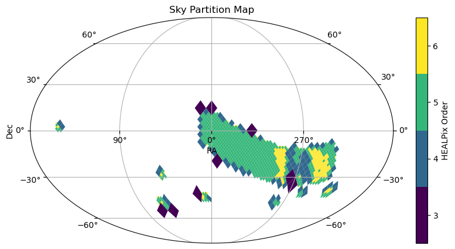

```python
fig = pz_cat.plot_pixels(plot_title="Sky Partition Map")
```

> **Figure 1:** The sky partitions of the lazily-loaded PZ catalog.

### 2.3. Table data

Show the first 10 rows of the PZ catalog.

```python
pz_cat.head(n=10)
```

| _healpix_29 | objectId | ra | dec | bpz_z_best | dnf_z_best | fzboost_z_best | gpz_z_best | knn_z_best | tpz_z_best |
| --- | --- | --- | --- | --- | --- | --- | --- | --- | --- |
| 1196750063051683238 | 767490864585903255 | 351.158498 | -17.850872 | 2.037524 | 2.082143 | 3.07092 | 0.537438 | 0.298913 | 0.660856 |
| 1196750064058168017 | 767490864585917450 | 351.154374 | -17.850893 | 0.374382 | 2.086247 | 1.159724 | 0.50978 | 0.29908 | 0.722733 |
| 1196750064998526636 | 767490864585917508 | 351.15485 | -17.849085 | 1.911994 | 2.082051 | 3.068399 | 0.532672 | 0.298944 | 0.615579 |
| 1196750065055727242 | 767490864585917509 | 351.155907 | -17.849272 | 0.72311 | 2.138241 | 1.013317 | 0.509443 | 0.299221 | 1.033516 |
| 1196750081847571868 | 767490864585901490 | 351.135249 | -17.849504 | 0.374776 | 2.081838 | 0.896646 | 0.52057 | 0.299029 | 0.702268 |
| 1196750082018620727 | 767490864585901486 | 351.132396 | -17.849868 | 0.618678 | 2.081431 | 1.092273 | 0.524669 | 0.299074 | 0.682498 |
| 1196750086503664774 | 767490864585917522 | 351.143259 | -17.848738 | 0.221739 | 2.086576 | 0.939482 | 0.509705 | 0.29904 | 0.435762 |
| 1196750086690209664 | 767490864585917523 | 351.144107 | -17.848468 | 0.276589 | 2.08648 | 1.047891 | 0.513002 | 0.299032 | 1.025774 |
| 1196750087070297366 | 767490864585903256 | 351.151689 | -17.850359 | 0.694074 | 2.081557 | 3.07025 | 0.52755 | 0.299037 | 0.721395 |
| 1196750088054841611 | 767490864585903265 | 351.152676 | -17.847991 | 1.494436 | 2.082051 | 3.067286 | 0.534329 | 0.298981 | 0.645686 |

10 rows × 9 columns

### 2.4. Plot N(pz)

$N(pz)$ refers to a histogram of the number of objects, $N$, as a function of photo-z, PZ.

To visualize how the PZ results vary by estimator, for each of the following fields plot the histogram N(pz) for $0<pz<3$ for each PZ estimator. These fields were selected for having deep coadd images in each of the six filters $ugrizy$.

```python
field_centers = {
    "DDF_ELAIS_S1": [9.5, -44.0],
    "DDF_ECDFS": [53.0, -28.1],
    "DDF_EDFS_b": [63.2, -47.8],
    "DDF_COSMOS": [150.1, 2.1],
    "New_Horizons": [289.4, -20.2],
    "Rubin_SV_225_-40": [225.0, -39.5],
    "Rubin_SV_320_-15": [320.2, -15.1],
}
```

Retrieve the names of the PZ estimators and store them in array `all_pz_codes`.

```python
all_pz_codes = []
for col in pz_cat.columns:
    if col.find('z_best') >= 0:
        all_pz_codes.append(col.split('_')[0])
print(all_pz_codes)
```

```
['bpz', 'dnf', 'fzboost', 'gpz', 'knn', 'tpz']
```

Create the histograms.

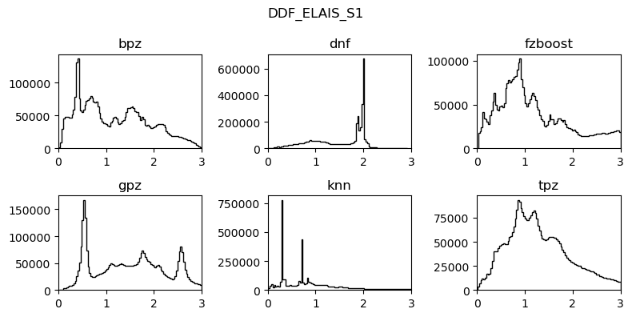

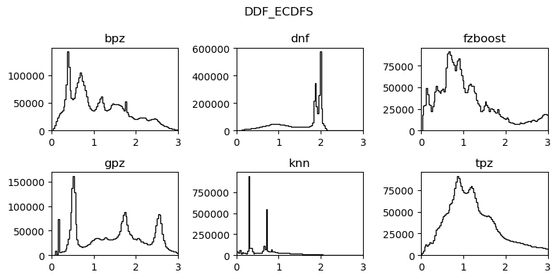

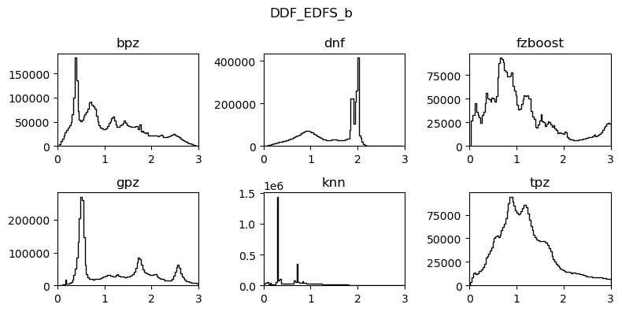

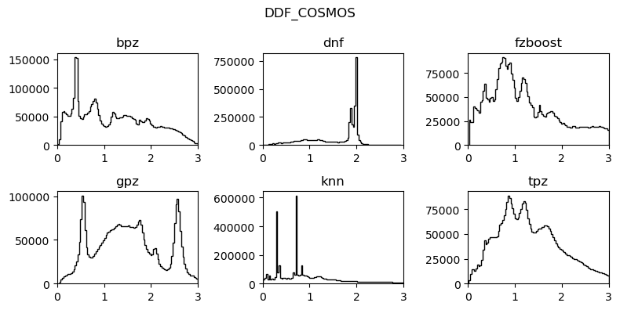

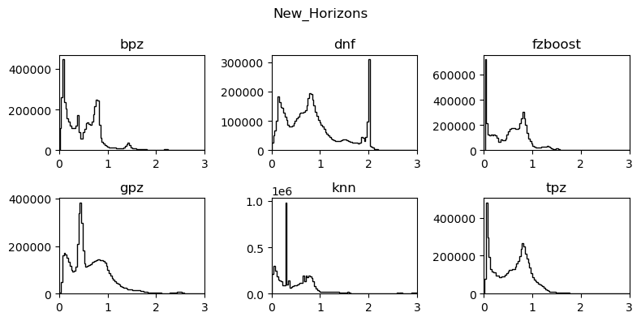

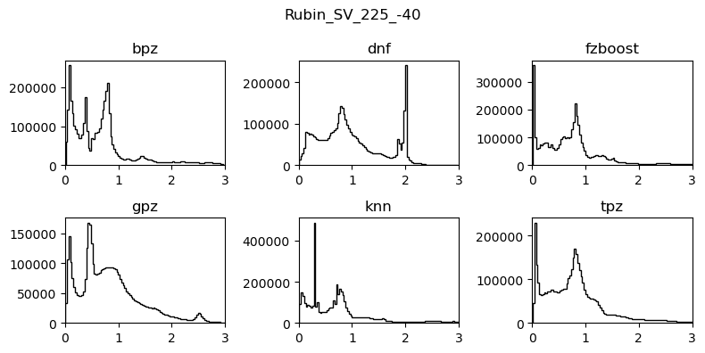

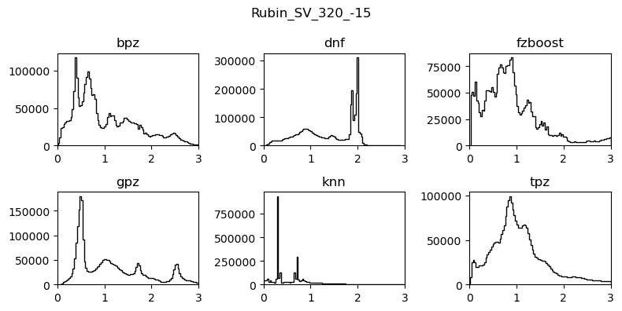

```python
for field in field_centers.keys():
    coords = field_centers[field]
    pz_cat_cone = pz_cat.cone_search(ra=coords[0], dec=coords[1],
                                     radius_arcsec=2.0 * 3600.0)
    pz_df_cone = pz_cat_cone.compute()
    fig, ax = plt.subplots(2, 3, figsize=(8, 4))
    ze = 0
    for i in range(2):
        for j in range(3):
            pz_code = all_pz_codes[ze]
            tx = (pz_df_cone[pz_code+'_z_best'] > 0) & \
                 (pz_df_cone[pz_code+'_z_best'] < 3)
            ax[i, j].hist(pz_df_cone[pz_code+'_z_best'][tx],
                          bins=100, histtype='step', color='black')
            ax[i, j].set_title(all_pz_codes[ze])
            ax[i, j].set_xlim([0, 3])
            ze += 1
            del pz_code, tx
    plt.suptitle(field)
    plt.tight_layout()
    del coords, pz_cat_cone, fig
```

> **Figure 2:** Histograms of the best PZ for each field, and each PZ estimator.

### 2.5. Compare estimates

For a given field, retrieve two PZ columns and make a plot comparing them.

For this example, use the DDF Elais S1, and compare the BZP results for best and mean PZ.

```python
field = 'DDF_ELAIS_S1'
coords = field_centers[field]
col1 = 'bpz_z_best'
col2 = 'bpz_z_mean'
pz_cat = lsdb.open_catalog(base_path / "object_photoz",
                           columns=[col1, col2])
pz_cat_cone = pz_cat.cone_search(ra=coords[0], dec=coords[1],
                                 radius_arcsec=2.0 * 3600.0)
pz_df_cone = pz_cat_cone.compute()
```

Option to display the table.

```python
# pz_df_cone
```

Set up to make a dynamic, interactive, 2D histogram to compare the two selected columns.

```python
points = hv.Points((pz_df_cone[col1], pz_df_cone[col2]))
boundsxy = (0, 0, 0, 0)
box = hv.streams.BoundsXY(source=points, bounds=boundsxy)
bounds = hv.DynamicMap(lambda bounds: hv.Bounds(bounds), streams=[box])
p = dynspread(datashade(points, cmap="Viridis"))
p = p.opts(width=600, height=300, padding=0.05, show_grid=True,
           xlim=(0, 3), ylim=(0, 6), xlabel=col1, ylabel=col2,
           tools=['box_select'])
```

Display the plot.

```python
p * bounds
```

[output not shown]

Clean up.

```python
del pz_cat
```

## 3. Join PZ and Object subsets

Small pandas dataframes ($<1$ million rows, $<1$ GB dataframe in-memory) can be read in to LSDB format and then joined to another LSDB table, as long as they both contain a common identifier column such as `objectId`.

Use the TAP service to obtain Objects within 0.7 degrees of the center of the COSMOS field (search radius set to keep the total <1 million).

```python
field = 'DDF_COSMOS'
coords = field_centers[field]
search_radius = 0.7
query = """SELECT objectId, coord_ra, coord_dec, g_cModelMag, r_cModelMag
        FROM dp2.Object
        WHERE CONTAINS(POINT('ICRS', coord_ra, coord_dec),
        CIRCLE('ICRS', {}, {}, {})) = 1 """.format(coords[0], coords[1], search_radius)
print(query)
job = tap_service.submit_job(query)
job.run()
job.wait(phases=['COMPLETED', 'ERROR'])
print('Job phase is', job.phase)
if job.phase == 'ERROR':
    job.raise_if_error()
assert job.phase == 'COMPLETED'
obj_cat_df = job.fetch_result().to_table().to_pandas()
print(len(obj_cat_df))
```

```
SELECT objectId, coord_ra, coord_dec, g_cModelMag, r_cModelMag
        FROM dp2.Object
        WHERE CONTAINS(POINT('ICRS', coord_ra, coord_dec),
        CIRCLE('ICRS', 150.1, 2.1, 0.7)) = 1
Job phase is COMPLETED
608145
```

Option to show `obj_cat_df`.

```python
# obj_cat_df
```

The `lsdb.from_dataframe` method requires that columns named "ra" and "dec" exist, so rename the coordinate columns and then convert to an `lsdb` data frame. Delete redundant versions of the table.

```python
obj_cat_rename = obj_cat_df.rename(columns={'coord_ra': 'ra', 'coord_dec': 'dec'})
obj_cat_lsdb = lsdb.from_dataframe(obj_cat_rename, catalog_name="object")
del obj_cat_rename, obj_cat_df
```

Option to display the first 10 rows of `obj_cat_lsdb`.

```python
# obj_cat_lsdb.head(n=10)
```

Retrieve the `objectId`, `ra`, `dec`, and `gpz_z_median` columns from the LSDB PZ catalog, and query for rows in the same field as defined above.

```python
pz_cat = lsdb.open_catalog(base_path / "object_photoz",
                           columns=['objectId', 'ra', 'dec', 'gpz_z_median'])
pz_cat_cone = pz_cat.cone_search(ra=coords[0], dec=coords[1],
                                 radius_arcsec=search_radius * 3600.0)
```

Use the `join` method to do an "inner" join on the shared column `objectId`. An "inner" join means the resulting catalog, `joined_cat`, only contains objects that appear in both `obj_cat_lsdb` and `pz_cat_cone`.

```python
joined_cat = pz_cat_cone.join(
    obj_cat_lsdb,
    left_on='objectId',
    right_on='objectId',
    suffix_method='all_columns',
)
```

Option to display the first 10 rows of `joined_cat`.

```python
joined_cat.head(n=10)
```

| _healpix_29 | objectId_object_photoz | ra_object_photoz | dec_object_photoz | gpz_z_median_object_photoz | objectId_object | ra_object | dec_object | g_cModelMag_object | r_cModelMag_object |
| --- | --- | --- | --- | --- | --- | --- | --- | --- | --- |
| 1917229402985056399 | 786346045893280050 | 150.193101 | 1.406708 | 0.824808 | 786346045893280050 | 150.193101 | 1.406708 | 25.8074 | 25.1101 |
| 1917229403002778086 | 786346045893280048 | 150.192226 | 1.40668 | 0.457578 | 786346045893280048 | 150.192226 | 1.40668 | 22.2682 | 20.9513 |
| 1917229403287839521 | 786346045893280109 | 150.194043 | 1.40817 | 1.761897 | 786346045893280109 | 150.194043 | 1.40817 | 25.691401 | 26.009199 |
| 1917229410617786451 | 786346045893279949 | 150.208491 | 1.409257 | 0.670406 | 786346045893279949 | 150.208491 | 1.409257 | 24.8484 | 24.1968 |
| 1917229410772948629 | 786346045893279957 | 150.207499 | 1.409857 | 1.568267 | 786346045893279957 | 150.207499 | 1.409857 | 25.5828 | 25.353701 |
| 1917229410853823956 | 786346045893252779 | 150.210302 | 1.409074 | 1.481173 | 786346045893252779 | 150.210302 | 1.409074 | 26.095699 | 26.0147 |
| 1917229411093865982 | 786346045893279960 | 150.21219 | 1.409931 | 2.192985 | 786346045893279960 | 150.21219 | 1.409931 | 26.6115 | 25.4974 |
| 1917229411213198760 | 786346045893279963 | 150.2114 | 1.410271 | 0.733254 | 786346045893279963 | 150.2114 | 1.410271 | 23.507799 | 22.775299 |
| 1917229411322710413 | 786346733088037028 | 150.211674 | 1.41131 | 1.29831 | 786346733088037028 | 150.211674 | 1.41131 | 24.824499 | 24.802099 |
| 1917229411394609214 | 786346045893279965 | 150.209246 | 1.410199 | 1.036921 | 786346045893279965 | 150.209246 | 1.410199 | 25.4676 | 25.134399 |

10 rows × 9 columns

As an example, plot the GPZ median redshift vs. the $g-r$ cModel color for all objects.

```python
points = hv.Points((joined_cat['gpz_z_median_object_photoz'],
                    joined_cat['g_cModelMag_object'] - joined_cat['r_cModelMag_object']))
boundsxy = (0, 0, 0, 0)
box = hv.streams.BoundsXY(source=points, bounds=boundsxy)
bounds = hv.DynamicMap(lambda bounds: hv.Bounds(bounds), streams=[box])
p = dynspread(datashade(points, cmap="Viridis"))
p = p.opts(width=600, height=300, padding=0.05, show_grid=True,
           xlim=(0, 3), ylim=(-4, 6), xlabel='gpz_z_median', ylabel='g-r cModelMag [mag]',
           tools=['box_select'])
```

```python
p * bounds
```

[output not shown]